# My visual data story

## The delivery timefor different Food Categories

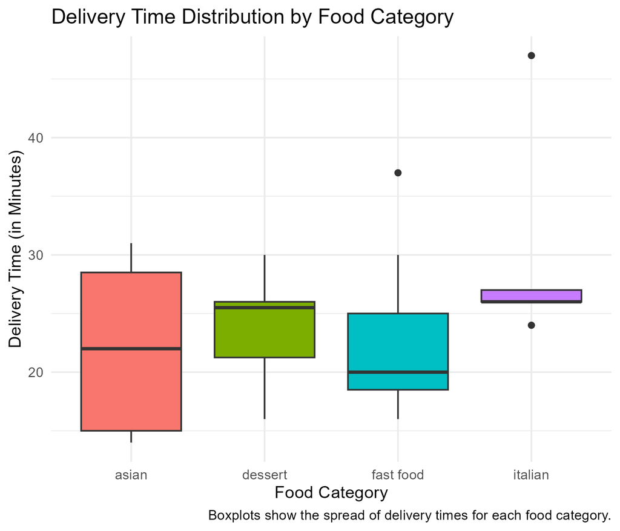

Boxplot of delivery times by food category

## How Does Order Cost Affect Delivery Time?

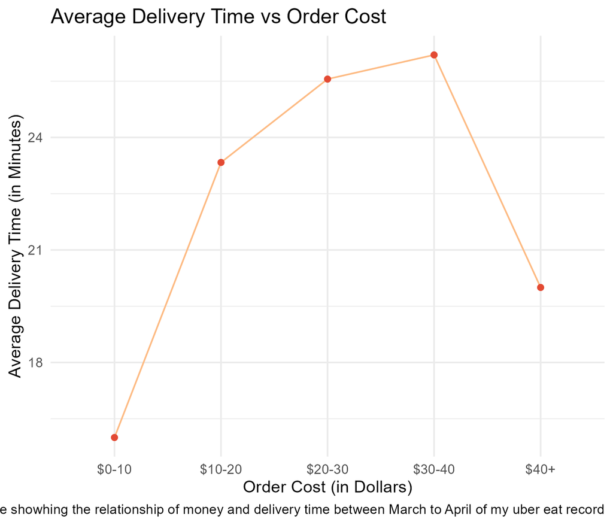

Line plot with points connected, showing average delivery time by cost bins

The line plot shows a increase relationship of order cost and average delivery time until the amount is over $40, order less than $10 (usually dessert) takes under average 18 minutes to arrive but amount between $30-40 takes more than 25 minutes to arrive. when the amount is over $40, it arrive less than 21 mintue average, this may because the amount is larger so takes the priority of the queue.